# Risk Factor Analysis

## Outcome Variable

**Outcome Variable:** wast_rec90d

## Predictor Variables

**Intervention Variable:** gagebrth

**Adjustment Set:**

- arm
- sex
- W_mage
- meducyrs
- feducyrs
- hhwealth_quart
- brthmon
- W_parity
- delta_W_mage
- delta_meducyrs
- delta_feducyrs
- delta_hhwealth_quart
- delta_brthmon
- delta_W_parity

## Stratifying Variables

The analysis was stratified on these variable(s):

- agecat
- studyid
- country

## Data Summary

| agecat | studyid | country | gagebrth | wast_rec90d | n_cell | n |
| --- | --- | --- | --- | --- | --- | --- |
| 0-24 months | ki1000108-CMC-V-BCS-2002 | INDIA | Full or late term | 0 | 68 | 301 |
| 0-24 months | ki1000108-CMC-V-BCS-2002 | INDIA | Full or late term | 1 | 119 | 301 |
| 0-24 months | ki1000108-CMC-V-BCS-2002 | INDIA | Preterm | 0 | 21 | 301 |
| 0-24 months | ki1000108-CMC-V-BCS-2002 | INDIA | Preterm | 1 | 28 | 301 |
| 0-24 months | ki1000108-CMC-V-BCS-2002 | INDIA | Early term | 0 | 21 | 301 |
| 0-24 months | ki1000108-CMC-V-BCS-2002 | INDIA | Early term | 1 | 44 | 301 |
| 0-24 months | ki1000108-IRC | INDIA | Full or late term | 0 | 92 | 382 |
| 0-24 months | ki1000108-IRC | INDIA | Full or late term | 1 | 134 | 382 |
| 0-24 months | ki1000108-IRC | INDIA | Preterm | 0 | 24 | 382 |
| 0-24 months | ki1000108-IRC | INDIA | Preterm | 1 | 29 | 382 |
| 0-24 months | ki1000108-IRC | INDIA | Early term | 0 | 39 | 382 |
| 0-24 months | ki1000108-IRC | INDIA | Early term | 1 | 64 | 382 |
| 0-24 months | ki1000109-EE | PAKISTAN | Full or late term | 0 | 4 | 257 |
| 0-24 months | ki1000109-EE | PAKISTAN | Full or late term | 1 | 6 | 257 |
| 0-24 months | ki1000109-EE | PAKISTAN | Preterm | 0 | 98 | 257 |
| 0-24 months | ki1000109-EE | PAKISTAN | Preterm | 1 | 78 | 257 |
| 0-24 months | ki1000109-EE | PAKISTAN | Early term | 0 | 48 | 257 |
| 0-24 months | ki1000109-EE | PAKISTAN | Early term | 1 | 23 | 257 |
| 0-24 months | ki1000304b-SAS-CompFeed | INDIA | Full or late term | 0 | 9 | 810 |
| 0-24 months | ki1000304b-SAS-CompFeed | INDIA | Full or late term | 1 | 5 | 810 |
| 0-24 months | ki1000304b-SAS-CompFeed | INDIA | Preterm | 0 | 463 | 810 |
| 0-24 months | ki1000304b-SAS-CompFeed | INDIA | Preterm | 1 | 282 | 810 |
| 0-24 months | ki1000304b-SAS-CompFeed | INDIA | Early term | 0 | 29 | 810 |
| 0-24 months | ki1000304b-SAS-CompFeed | INDIA | Early term | 1 | 22 | 810 |
| 0-24 months | ki1017093c-NIH-Crypto | BANGLADESH | Full or late term | 0 | 16 | 311 |
| 0-24 months | ki1017093c-NIH-Crypto | BANGLADESH | Full or late term | 1 | 26 | 311 |
| 0-24 months | ki1017093c-NIH-Crypto | BANGLADESH | Preterm | 0 | 57 | 311 |
| 0-24 months | ki1017093c-NIH-Crypto | BANGLADESH | Preterm | 1 | 92 | 311 |
| 0-24 months | ki1017093c-NIH-Crypto | BANGLADESH | Early term | 0 | 44 | 311 |
| 0-24 months | ki1017093c-NIH-Crypto | BANGLADESH | Early term | 1 | 76 | 311 |

[output cut: 186 more lines]

The following strata were considered:

- agecat: 0-24 months, studyid: ki1000108-CMC-V-BCS-2002, country: INDIA
- agecat: 0-24 months, studyid: ki1000108-IRC, country: INDIA
- agecat: 0-24 months, studyid: ki1000109-EE, country: PAKISTAN
- agecat: 0-24 months, studyid: ki1000304b-SAS-CompFeed, country: INDIA
- agecat: 0-24 months, studyid: ki1017093c-NIH-Crypto, country: BANGLADESH
- agecat: 0-24 months, studyid: ki1066203-TanzaniaChild2, country: TANZANIA, UNITED REPUBLIC OF
- agecat: 0-24 months, studyid: ki1101329-Keneba, country: GAMBIA
- agecat: 0-24 months, studyid: ki1119695-PROBIT, country: BELARUS
- agecat: 0-24 months, studyid: ki1135781-COHORTS, country: GUATEMALA
- agecat: 0-24 months, studyid: ki1135781-COHORTS, country: INDIA
- agecat: 0-24 months, studyid: ki1135781-COHORTS, country: PHILIPPINES
- agecat: 0-24 months, studyid: kiGH5241-JiVitA-3, country: BANGLADESH
- agecat: 0-6 months, studyid: ki1000108-CMC-V-BCS-2002, country: INDIA
- agecat: 0-6 months, studyid: ki1000108-IRC, country: INDIA
- agecat: 0-6 months, studyid: ki1000109-EE, country: PAKISTAN
- agecat: 0-6 months, studyid: ki1000304b-SAS-CompFeed, country: INDIA
- agecat: 0-6 months, studyid: ki1017093c-NIH-Crypto, country: BANGLADESH
- agecat: 0-6 months, studyid: ki1066203-TanzaniaChild2, country: TANZANIA, UNITED REPUBLIC OF
- agecat: 0-6 months, studyid: ki1101329-Keneba, country: GAMBIA
- agecat: 0-6 months, studyid: ki1119695-PROBIT, country: BELARUS
- agecat: 0-6 months, studyid: ki1135781-COHORTS, country: GUATEMALA
- agecat: 0-6 months, studyid: ki1135781-COHORTS, country: INDIA
- agecat: 0-6 months, studyid: ki1135781-COHORTS, country: PHILIPPINES
- agecat: 0-6 months, studyid: kiGH5241-JiVitA-3, country: BANGLADESH
- agecat: 6-24 months, studyid: ki1000108-CMC-V-BCS-2002, country: INDIA
- agecat: 6-24 months, studyid: ki1000108-IRC, country: INDIA
- agecat: 6-24 months, studyid: ki1000109-EE, country: PAKISTAN
- agecat: 6-24 months, studyid: ki1000304b-SAS-CompFeed, country: INDIA
- agecat: 6-24 months, studyid: ki1017093c-NIH-Crypto, country: BANGLADESH
- agecat: 6-24 months, studyid: ki1066203-TanzaniaChild2, country: TANZANIA, UNITED REPUBLIC OF
- agecat: 6-24 months, studyid: ki1101329-Keneba, country: GAMBIA
- agecat: 6-24 months, studyid: ki1119695-PROBIT, country: BELARUS
- agecat: 6-24 months, studyid: ki1135781-COHORTS, country: GUATEMALA
- agecat: 6-24 months, studyid: ki1135781-COHORTS, country: INDIA
- agecat: 6-24 months, studyid: ki1135781-COHORTS, country: PHILIPPINES
- agecat: 6-24 months, studyid: kiGH5241-JiVitA-3, country: BANGLADESH

### Dropped Strata

Some strata were dropped due to rare outcomes:

- agecat: 0-24 months, studyid: ki1000109-EE, country: PAKISTAN
- agecat: 0-6 months, studyid: ki1000109-EE, country: PAKISTAN
- agecat: 0-6 months, studyid: ki1000304b-SAS-CompFeed, country: INDIA
- agecat: 0-6 months, studyid: ki1017093c-NIH-Crypto, country: BANGLADESH
- agecat: 6-24 months, studyid: ki1000109-EE, country: PAKISTAN
- agecat: 6-24 months, studyid: ki1000304b-SAS-CompFeed, country: INDIA
- agecat: 6-24 months, studyid: ki1017093c-NIH-Crypto, country: BANGLADESH
- agecat: 6-24 months, studyid: ki1119695-PROBIT, country: BELARUS
- agecat: 6-24 months, studyid: ki1135781-COHORTS, country: GUATEMALA
- agecat: 6-24 months, studyid: ki1135781-COHORTS, country: INDIA
- agecat: 6-24 months, studyid: kiGH5241-JiVitA-3, country: BANGLADESH

## Methods Detail

We’re interested in the causal parameters $E[Y_a]$ for all values of $a \in \mathcal{A}$. These parameters represent the mean outcome if, possibly contrary to fact, we intervened to set all units to have $A=a$. Under the randomization and positivity assumptions, these are identified by the statistical parameters $\psi_a=E_W[E_{Y|A,W}(Y|A=a,W)]$. In addition, we’re interested in the mean of $Y$, $E[Y]$ under no intervention (the observed mean). We will estimate these parameters by using SuperLearner to fit the relevant likelihood factors – $E_{Y|A,W}(Y|A=a,W)$ and $p(A=a|W)$, and then updating our likelihood fit using a joint TMLE.

For unadjusted analyses ($W=\{\}$), initial likelihoods were estimated using Lrnr_glm to estimate the simple $E(Y|A)$ and Lrnr_mean to estimate $p(A)$. For adjusted analyses, a small library containing Lrnr_glmnet, Lrnr_xgboost, and Lrnr_mean was used.

Having estimated these parameters, we will then use the delta method to estimate relative risks and attributable risks relative to a prespecified baseline level of $A$.

# Results Detail

## Results Plots

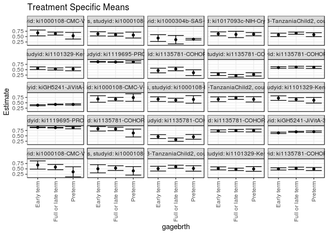

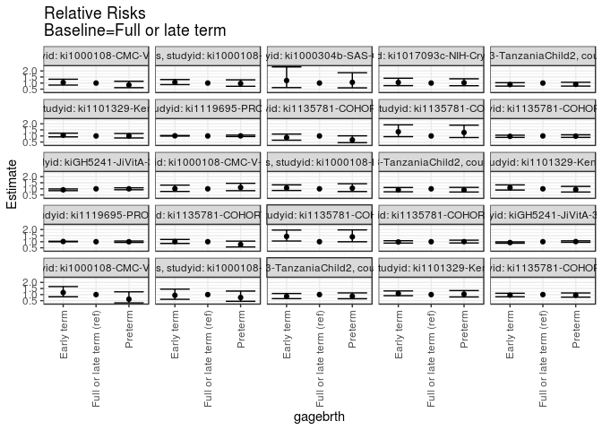

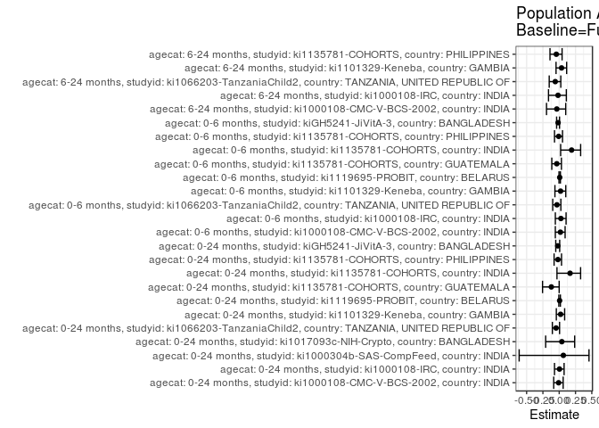

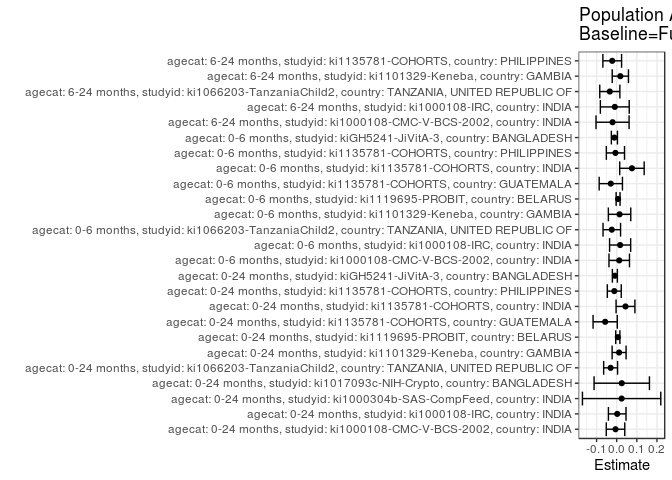

## Results Table

### Parameter: TSM

| agecat | studyid | country | intervention_level | baseline_level | estimate | ci_lower | ci_upper |
| --- | --- | --- | --- | --- | --- | --- | --- |
| 0-24 months | ki1000108-CMC-V-BCS-2002 | INDIA | Full or late term | NA | 0.6405048 | 0.5709058 | 0.7101037 |
| 0-24 months | ki1000108-CMC-V-BCS-2002 | INDIA | Preterm | NA | 0.5404702 | 0.3857233 | 0.6952170 |
| 0-24 months | ki1000108-CMC-V-BCS-2002 | INDIA | Early term | NA | 0.6710641 | 0.5353720 | 0.8067561 |
| 0-24 months | ki1000108-IRC | INDIA | Full or late term | NA | 0.5917686 | 0.5195725 | 0.6639647 |
| 0-24 months | ki1000108-IRC | INDIA | Preterm | NA | 0.5710518 | 0.4340957 | 0.7080080 |
| 0-24 months | ki1000108-IRC | INDIA | Early term | NA | 0.6278062 | 0.5328861 | 0.7227263 |
| 0-24 months | ki1000304b-SAS-CompFeed | INDIA | Full or late term | NA | 0.3571429 | 0.1608018 | 0.5534839 |
| 0-24 months | ki1000304b-SAS-CompFeed | INDIA | Preterm | NA | 0.3785235 | 0.3421693 | 0.4148777 |
| 0-24 months | ki1000304b-SAS-CompFeed | INDIA | Early term | NA | 0.4313725 | 0.2762267 | 0.5865184 |
| 0-24 months | ki1017093c-NIH-Crypto | BANGLADESH | Full or late term | NA | 0.5987361 | 0.4518788 | 0.7455934 |
| 0-24 months | ki1017093c-NIH-Crypto | BANGLADESH | Preterm | NA | 0.6149470 | 0.5378580 | 0.6920361 |
| 0-24 months | ki1017093c-NIH-Crypto | BANGLADESH | Early term | NA | 0.6285476 | 0.5378901 | 0.7192050 |
| 0-24 months | ki1066203-TanzaniaChild2 | TANZANIA, UNITED REPUBLIC OF | Full or late term | NA | 0.6594612 | 0.6086351 | 0.7102872 |
| 0-24 months | ki1066203-TanzaniaChild2 | TANZANIA, UNITED REPUBLIC OF | Preterm | NA | 0.5902414 | 0.4984584 | 0.6820244 |
| 0-24 months | ki1066203-TanzaniaChild2 | TANZANIA, UNITED REPUBLIC OF | Early term | NA | 0.5811613 | 0.5008358 | 0.6614868 |
| 0-24 months | ki1101329-Keneba | GAMBIA | Full or late term | NA | 0.5317173 | 0.4831785 | 0.5802562 |
| 0-24 months | ki1101329-Keneba | GAMBIA | Preterm | NA | 0.5323238 | 0.4479810 | 0.6166666 |
| 0-24 months | ki1101329-Keneba | GAMBIA | Early term | NA | 0.5660226 | 0.5037404 | 0.6283048 |
| 0-24 months | ki1119695-PROBIT | BELARUS | Full or late term | NA | 0.8558009 | 0.8409859 | 0.8706159 |
| 0-24 months | ki1119695-PROBIT | BELARUS | Preterm | NA | 0.8618620 | 0.8125492 | 0.9111748 |
| 0-24 months | ki1119695-PROBIT | BELARUS | Early term | NA | 0.8660670 | 0.8514907 | 0.8806434 |
| 0-24 months | ki1135781-COHORTS | GUATEMALA | Full or late term | NA | 0.5323608 | 0.4466036 | 0.6181180 |
| 0-24 months | ki1135781-COHORTS | GUATEMALA | Preterm | NA | 0.3591698 | 0.2258666 | 0.4924730 |
| 0-24 months | ki1135781-COHORTS | GUATEMALA | Early term | NA | 0.4606833 | 0.3518552 | 0.5695113 |
| 0-24 months | ki1135781-COHORTS | INDIA | Full or late term | NA | 0.2183410 | 0.1584948 | 0.2781871 |
| 0-24 months | ki1135781-COHORTS | INDIA | Preterm | NA | 0.2799417 | 0.2035768 | 0.3563065 |
| 0-24 months | ki1135781-COHORTS | INDIA | Early term | NA | 0.2930810 | 0.2270399 | 0.3591221 |
| 0-24 months | ki1135781-COHORTS | PHILIPPINES | Full or late term | NA | 0.6180113 | 0.5749912 | 0.6610313 |
| 0-24 months | ki1135781-COHORTS | PHILIPPINES | Preterm | NA | 0.6069650 | 0.5567681 | 0.6571619 |
| 0-24 months | ki1135781-COHORTS | PHILIPPINES | Early term | NA | 0.5983593 | 0.5607915 | 0.6359271 |
| 0-24 months | kiGH5241-JiVitA-3 | BANGLADESH | Full or late term | NA | 0.4203270 | 0.4023616 | 0.4382924 |
| 0-24 months | kiGH5241-JiVitA-3 | BANGLADESH | Preterm | NA | 0.4207602 | 0.3923602 | 0.4491602 |
| 0-24 months | kiGH5241-JiVitA-3 | BANGLADESH | Early term | NA | 0.3858550 | 0.3614493 | 0.4102606 |
| 0-6 months | ki1000108-CMC-V-BCS-2002 | INDIA | Full or late term | NA | 0.6666667 | 0.5821538 | 0.7511795 |
| 0-6 months | ki1000108-CMC-V-BCS-2002 | INDIA | Preterm | NA | 0.7407407 | 0.5657628 | 0.9157187 |
| 0-6 months | ki1000108-CMC-V-BCS-2002 | INDIA | Early term | NA | 0.6750000 | 0.5250907 | 0.8249093 |
| 0-6 months | ki1000108-IRC | INDIA | Full or late term | NA | 0.6222222 | 0.5361698 | 0.7082747 |
| 0-6 months | ki1000108-IRC | INDIA | Preterm | NA | 0.6538462 | 0.4797295 | 0.8279628 |
| 0-6 months | ki1000108-IRC | INDIA | Early term | NA | 0.6666667 | 0.5568093 | 0.7765240 |
| 0-6 months | ki1066203-TanzaniaChild2 | TANZANIA, UNITED REPUBLIC OF | Full or late term | NA | 0.7237996 | 0.6581714 | 0.7894277 |
| 0-6 months | ki1066203-TanzaniaChild2 | TANZANIA, UNITED REPUBLIC OF | Preterm | NA | 0.6570295 | 0.5327330 | 0.7813260 |
| 0-6 months | ki1066203-TanzaniaChild2 | TANZANIA, UNITED REPUBLIC OF | Early term | NA | 0.6630316 | 0.5508575 | 0.7752058 |
| 0-6 months | ki1101329-Keneba | GAMBIA | Full or late term | NA | 0.6550905 | 0.5741544 | 0.7360266 |
| 0-6 months | ki1101329-Keneba | GAMBIA | Preterm | NA | 0.6151982 | 0.4840151 | 0.7463812 |
| 0-6 months | ki1101329-Keneba | GAMBIA | Early term | NA | 0.7153225 | 0.6085675 | 0.8220775 |
| 0-6 months | ki1119695-PROBIT | BELARUS | Full or late term | NA | 0.8787239 | 0.8647040 | 0.8927438 |
| 0-6 months | ki1119695-PROBIT | BELARUS | Preterm | NA | 0.8763070 | 0.8252911 | 0.9273229 |
| 0-6 months | ki1119695-PROBIT | BELARUS | Early term | NA | 0.8929619 | 0.8792688 | 0.9066549 |
| 0-6 months | ki1135781-COHORTS | GUATEMALA | Full or late term | NA | 0.8181818 | 0.7368393 | 0.8995243 |
| 0-6 months | ki1135781-COHORTS | GUATEMALA | Preterm | NA | 0.6296296 | 0.4457667 | 0.8134926 |
| 0-6 months | ki1135781-COHORTS | GUATEMALA | Early term | NA | 0.8260870 | 0.7207224 | 0.9314515 |
| 0-6 months | ki1135781-COHORTS | INDIA | Full or late term | NA | 0.3226227 | 0.2461864 | 0.3990591 |
| 0-6 months | ki1135781-COHORTS | INDIA | Preterm | NA | 0.4519529 | 0.3408482 | 0.5630576 |
| 0-6 months | ki1135781-COHORTS | INDIA | Early term | NA | 0.4636875 | 0.3724722 | 0.5549028 |
| 0-6 months | ki1135781-COHORTS | PHILIPPINES | Full or late term | NA | 0.7429360 | 0.6881693 | 0.7977026 |
| 0-6 months | ki1135781-COHORTS | PHILIPPINES | Preterm | NA | 0.7463321 | 0.6812336 | 0.8114306 |
| 0-6 months | ki1135781-COHORTS | PHILIPPINES | Early term | NA | 0.7281498 | 0.6788500 | 0.7774496 |
| 0-6 months | kiGH5241-JiVitA-3 | BANGLADESH | Full or late term | NA | 0.6862079 | 0.6646296 | 0.7077863 |
| 0-6 months | kiGH5241-JiVitA-3 | BANGLADESH | Preterm | NA | 0.6932776 | 0.6591425 | 0.7274128 |
| 0-6 months | kiGH5241-JiVitA-3 | BANGLADESH | Early term | NA | 0.6384321 | 0.6072091 | 0.6696550 |
| 6-24 months | ki1000108-CMC-V-BCS-2002 | INDIA | Full or late term | NA | 0.5820896 | 0.4594727 | 0.7047064 |
| 6-24 months | ki1000108-CMC-V-BCS-2002 | INDIA | Preterm | NA | 0.3636364 | 0.1308138 | 0.5964590 |
| 6-24 months | ki1000108-CMC-V-BCS-2002 | INDIA | Early term | NA | 0.6800000 | 0.4890151 | 0.8709849 |
| 6-24 months | ki1000108-IRC | INDIA | Full or late term | NA | 0.5358895 | 0.4272412 | 0.6445378 |
| 6-24 months | ki1000108-IRC | INDIA | Preterm | NA | 0.4073017 | 0.2090242 | 0.6055792 |
| 6-24 months | ki1000108-IRC | INDIA | Early term | NA | 0.5054876 | 0.3150889 | 0.6958862 |
| 6-24 months | ki1066203-TanzaniaChild2 | TANZANIA, UNITED REPUBLIC OF | Full or late term | NA | 0.5999964 | 0.5281278 | 0.6718650 |
| 6-24 months | ki1066203-TanzaniaChild2 | TANZANIA, UNITED REPUBLIC OF | Preterm | NA | 0.5198981 | 0.3930012 | 0.6467951 |
| 6-24 months | ki1066203-TanzaniaChild2 | TANZANIA, UNITED REPUBLIC OF | Early term | NA | 0.5110267 | 0.4016639 | 0.6203896 |
| 6-24 months | ki1101329-Keneba | GAMBIA | Full or late term | NA | 0.4791147 | 0.4224226 | 0.5358068 |
| 6-24 months | ki1101329-Keneba | GAMBIA | Preterm | NA | 0.4967039 | 0.3872654 | 0.6061424 |
| 6-24 months | ki1101329-Keneba | GAMBIA | Early term | NA | 0.5217810 | 0.4518297 | 0.5917324 |
| 6-24 months | ki1135781-COHORTS | PHILIPPINES | Full or late term | NA | 0.5239130 | 0.4660805 | 0.5817454 |
| 6-24 months | ki1135781-COHORTS | PHILIPPINES | Preterm | NA | 0.4957621 | 0.4249337 | 0.5665905 |
| 6-24 months | ki1135781-COHORTS | PHILIPPINES | Early term | NA | 0.4995652 | 0.4472415 | 0.5518889 |

### Parameter: E(Y)

| agecat | studyid | country | intervention_level | baseline_level | estimate | ci_lower | ci_upper |
| --- | --- | --- | --- | --- | --- | --- | --- |
| 0-24 months | ki1000108-CMC-V-BCS-2002 | INDIA | NA | NA | 0.6345515 | 0.5770351 | 0.6920679 |
| 0-24 months | ki1000108-IRC | INDIA | NA | NA | 0.5942408 | 0.5412823 | 0.6471994 |
| 0-24 months | ki1000304b-SAS-CompFeed | INDIA | NA | NA | 0.3814815 | 0.3462984 | 0.4166645 |
| 0-24 months | ki1017093c-NIH-Crypto | BANGLADESH | NA | NA | 0.6237942 | 0.5698223 | 0.6777662 |
| 0-24 months | ki1066203-TanzaniaChild2 | TANZANIA, UNITED REPUBLIC OF | NA | NA | 0.6291291 | 0.5901846 | 0.6680736 |
| 0-24 months | ki1101329-Keneba | GAMBIA | NA | NA | 0.5435467 | 0.5088559 | 0.5782375 |
| 0-24 months | ki1119695-PROBIT | BELARUS | NA | NA | 0.8612051 | 0.8511051 | 0.8713052 |
| 0-24 months | ki1135781-COHORTS | GUATEMALA | NA | NA | 0.4750000 | 0.4147665 | 0.5352335 |
| 0-24 months | ki1135781-COHORTS | INDIA | NA | NA | 0.2619503 | 0.2237649 | 0.3001357 |
| 0-24 months | ki1135781-COHORTS | PHILIPPINES | NA | NA | 0.6059701 | 0.5813402 | 0.6306001 |
| 0-24 months | kiGH5241-JiVitA-3 | BANGLADESH | NA | NA | 0.4111748 | 0.3982807 | 0.4240689 |
| 0-6 months | ki1000108-CMC-V-BCS-2002 | INDIA | NA | NA | 0.6791444 | 0.6111760 | 0.7471128 |
| 0-6 months | ki1000108-IRC | INDIA | NA | NA | 0.6391304 | 0.5756367 | 0.7026242 |
| 0-6 months | ki1066203-TanzaniaChild2 | TANZANIA, UNITED REPUBLIC OF | NA | NA | 0.6993671 | 0.6481378 | 0.7505964 |
| 0-6 months | ki1101329-Keneba | GAMBIA | NA | NA | 0.6692607 | 0.6118880 | 0.7266334 |
| 0-6 months | ki1119695-PROBIT | BELARUS | NA | NA | 0.8855266 | 0.8758983 | 0.8951550 |
| 0-6 months | ki1135781-COHORTS | GUATEMALA | NA | NA | 0.7888199 | 0.7258783 | 0.8517615 |
| 0-6 months | ki1135781-COHORTS | INDIA | NA | NA | 0.3982558 | 0.3464489 | 0.4500628 |
| 0-6 months | ki1135781-COHORTS | PHILIPPINES | NA | NA | 0.7365591 | 0.7047881 | 0.7683302 |
| 0-6 months | kiGH5241-JiVitA-3 | BANGLADESH | NA | NA | 0.6746988 | 0.6589571 | 0.6904405 |
| 6-24 months | ki1000108-CMC-V-BCS-2002 | INDIA | NA | NA | 0.5614035 | 0.4645960 | 0.6582110 |
| 6-24 months | ki1000108-IRC | INDIA | NA | NA | 0.5263158 | 0.4415211 | 0.6111105 |
| 6-24 months | ki1066203-TanzaniaChild2 | TANZANIA, UNITED REPUBLIC OF | NA | NA | 0.5657143 | 0.5118874 | 0.6195411 |
| 6-24 months | ki1101329-Keneba | GAMBIA | NA | NA | 0.4971264 | 0.4573928 | 0.5368601 |
| 6-24 months | ki1135781-COHORTS | PHILIPPINES | NA | NA | 0.5016112 | 0.4676556 | 0.5355667 |

### Parameter: RR

| agecat | studyid | country | intervention_level | baseline_level | estimate | ci_lower | ci_upper |
| --- | --- | --- | --- | --- | --- | --- | --- |
| 0-24 months | ki1000108-CMC-V-BCS-2002 | INDIA | Full or late term | Full or late term | 1.0000000 | 1.0000000 | 1.0000000 |
| 0-24 months | ki1000108-CMC-V-BCS-2002 | INDIA | Preterm | Full or late term | 0.8438191 | 0.6210793 | 1.1464409 |
| 0-24 months | ki1000108-CMC-V-BCS-2002 | INDIA | Early term | Full or late term | 1.0477113 | 0.8343893 | 1.3155717 |
| 0-24 months | ki1000108-IRC | INDIA | Full or late term | Full or late term | 1.0000000 | 1.0000000 | 1.0000000 |
| 0-24 months | ki1000108-IRC | INDIA | Preterm | Full or late term | 0.9649918 | 0.7366326 | 1.2641433 |
| 0-24 months | ki1000108-IRC | INDIA | Early term | Full or late term | 1.0608982 | 0.8732787 | 1.2888267 |
| 0-24 months | ki1000304b-SAS-CompFeed | INDIA | Full or late term | Full or late term | 1.0000000 | 1.0000000 | 1.0000000 |
| 0-24 months | ki1000304b-SAS-CompFeed | INDIA | Preterm | Full or late term | 1.0598658 | 0.6065874 | 1.8518608 |
| 0-24 months | ki1000304b-SAS-CompFeed | INDIA | Early term | Full or late term | 1.2078431 | 0.6262172 | 2.3296789 |
| 0-24 months | ki1017093c-NIH-Crypto | BANGLADESH | Full or late term | Full or late term | 1.0000000 | 1.0000000 | 1.0000000 |
| 0-24 months | ki1017093c-NIH-Crypto | BANGLADESH | Preterm | Full or late term | 1.0270752 | 0.7796657 | 1.3529947 |
| 0-24 months | ki1017093c-NIH-Crypto | BANGLADESH | Early term | Full or late term | 1.0497907 | 0.7891838 | 1.3964560 |
| 0-24 months | ki1066203-TanzaniaChild2 | TANZANIA, UNITED REPUBLIC OF | Full or late term | Full or late term | 1.0000000 | 1.0000000 | 1.0000000 |
| 0-24 months | ki1066203-TanzaniaChild2 | TANZANIA, UNITED REPUBLIC OF | Preterm | Full or late term | 0.8950359 | 0.7523812 | 1.0647386 |
| 0-24 months | ki1066203-TanzaniaChild2 | TANZANIA, UNITED REPUBLIC OF | Early term | Full or late term | 0.8812670 | 0.7522891 | 1.0323577 |
| 0-24 months | ki1101329-Keneba | GAMBIA | Full or late term | Full or late term | 1.0000000 | 1.0000000 | 1.0000000 |
| 0-24 months | ki1101329-Keneba | GAMBIA | Preterm | Full or late term | 1.0011406 | 0.8340872 | 1.2016519 |
| 0-24 months | ki1101329-Keneba | GAMBIA | Early term | Full or late term | 1.0645178 | 0.9227952 | 1.2280061 |
| 0-24 months | ki1119695-PROBIT | BELARUS | Full or late term | Full or late term | 1.0000000 | 1.0000000 | 1.0000000 |
| 0-24 months | ki1119695-PROBIT | BELARUS | Preterm | Full or late term | 1.0070824 | 0.9486454 | 1.0691191 |
| 0-24 months | ki1119695-PROBIT | BELARUS | Early term | Full or late term | 1.0119960 | 0.9878519 | 1.0367301 |
| 0-24 months | ki1135781-COHORTS | GUATEMALA | Full or late term | Full or late term | 1.0000000 | 1.0000000 | 1.0000000 |
| 0-24 months | ki1135781-COHORTS | GUATEMALA | Preterm | Full or late term | 0.6746736 | 0.4501741 | 1.0111299 |
| 0-24 months | ki1135781-COHORTS | GUATEMALA | Early term | Full or late term | 0.8653591 | 0.6501856 | 1.1517424 |
| 0-24 months | ki1135781-COHORTS | INDIA | Full or late term | Full or late term | 1.0000000 | 1.0000000 | 1.0000000 |
| 0-24 months | ki1135781-COHORTS | INDIA | Preterm | Full or late term | 1.2821309 | 0.8711383 | 1.8870247 |
| 0-24 months | ki1135781-COHORTS | INDIA | Early term | Full or late term | 1.3423087 | 0.9425119 | 1.9116922 |
| 0-24 months | ki1135781-COHORTS | PHILIPPINES | Full or late term | Full or late term | 1.0000000 | 1.0000000 | 1.0000000 |
| 0-24 months | ki1135781-COHORTS | PHILIPPINES | Preterm | Full or late term | 0.9821261 | 0.8815654 | 1.0941578 |
| 0-24 months | ki1135781-COHORTS | PHILIPPINES | Early term | Full or late term | 0.9682013 | 0.8816713 | 1.0632235 |
| 0-24 months | kiGH5241-JiVitA-3 | BANGLADESH | Full or late term | Full or late term | 1.0000000 | 1.0000000 | 1.0000000 |
| 0-24 months | kiGH5241-JiVitA-3 | BANGLADESH | Preterm | Full or late term | 1.0010307 | 0.9241922 | 1.0842575 |
| 0-24 months | kiGH5241-JiVitA-3 | BANGLADESH | Early term | Full or late term | 0.9179877 | 0.8505432 | 0.9907803 |
| 0-6 months | ki1000108-CMC-V-BCS-2002 | INDIA | Full or late term | Full or late term | 1.0000000 | 1.0000000 | 1.0000000 |
| 0-6 months | ki1000108-CMC-V-BCS-2002 | INDIA | Preterm | Full or late term | 1.1111111 | 0.8498176 | 1.4527446 |
| 0-6 months | ki1000108-CMC-V-BCS-2002 | INDIA | Early term | Full or late term | 1.0125000 | 0.7840402 | 1.3075303 |
| 0-6 months | ki1000108-IRC | INDIA | Full or late term | Full or late term | 1.0000000 | 1.0000000 | 1.0000000 |
| 0-6 months | ki1000108-IRC | INDIA | Preterm | Full or late term | 1.0508242 | 0.7784047 | 1.4185827 |
| 0-6 months | ki1000108-IRC | INDIA | Early term | Full or late term | 1.0714286 | 0.8640328 | 1.3286061 |
| 0-6 months | ki1066203-TanzaniaChild2 | TANZANIA, UNITED REPUBLIC OF | Full or late term | Full or late term | 1.0000000 | 1.0000000 | 1.0000000 |
| 0-6 months | ki1066203-TanzaniaChild2 | TANZANIA, UNITED REPUBLIC OF | Preterm | Full or late term | 0.9077506 | 0.7359669 | 1.1196307 |
| 0-6 months | ki1066203-TanzaniaChild2 | TANZANIA, UNITED REPUBLIC OF | Early term | Full or late term | 0.9160432 | 0.7560002 | 1.1099667 |
| 0-6 months | ki1101329-Keneba | GAMBIA | Full or late term | Full or late term | 1.0000000 | 1.0000000 | 1.0000000 |
| 0-6 months | ki1101329-Keneba | GAMBIA | Preterm | Full or late term | 0.9391041 | 0.7349982 | 1.1998893 |
| 0-6 months | ki1101329-Keneba | GAMBIA | Early term | Full or late term | 1.0919445 | 0.9003602 | 1.3242954 |
| 0-6 months | ki1119695-PROBIT | BELARUS | Full or late term | Full or late term | 1.0000000 | 1.0000000 | 1.0000000 |
| 0-6 months | ki1119695-PROBIT | BELARUS | Preterm | Full or late term | 0.9972495 | 0.9388316 | 1.0593025 |
| 0-6 months | ki1119695-PROBIT | BELARUS | Early term | Full or late term | 1.0162030 | 0.9939602 | 1.0389436 |
| 0-6 months | ki1135781-COHORTS | GUATEMALA | Full or late term | Full or late term | 1.0000000 | 1.0000000 | 1.0000000 |
| 0-6 months | ki1135781-COHORTS | GUATEMALA | Preterm | Full or late term | 0.7695473 | 0.5652821 | 1.0476239 |
| 0-6 months | ki1135781-COHORTS | GUATEMALA | Early term | Full or late term | 1.0096618 | 0.8589016 | 1.1868846 |
| 0-6 months | ki1135781-COHORTS | INDIA | Full or late term | Full or late term | 1.0000000 | 1.0000000 | 1.0000000 |
| 0-6 months | ki1135781-COHORTS | INDIA | Preterm | Full or late term | 1.4008712 | 0.9963414 | 1.9696463 |
| 0-6 months | ki1135781-COHORTS | INDIA | Early term | Full or late term | 1.4372437 | 1.0565583 | 1.9550927 |
| 0-6 months | ki1135781-COHORTS | PHILIPPINES | Full or late term | Full or late term | 1.0000000 | 1.0000000 | 1.0000000 |
| 0-6 months | ki1135781-COHORTS | PHILIPPINES | Preterm | Full or late term | 1.0045713 | 0.8961499 | 1.1261102 |
| 0-6 months | ki1135781-COHORTS | PHILIPPINES | Early term | Full or late term | 0.9800976 | 0.8868495 | 1.0831504 |
| 0-6 months | kiGH5241-JiVitA-3 | BANGLADESH | Full or late term | Full or late term | 1.0000000 | 1.0000000 | 1.0000000 |
| 0-6 months | kiGH5241-JiVitA-3 | BANGLADESH | Preterm | Full or late term | 1.0103026 | 0.9529883 | 1.0710639 |
| 0-6 months | kiGH5241-JiVitA-3 | BANGLADESH | Early term | Full or late term | 0.9303770 | 0.8778638 | 0.9860314 |
| 6-24 months | ki1000108-CMC-V-BCS-2002 | INDIA | Full or late term | Full or late term | 1.0000000 | 1.0000000 | 1.0000000 |
| 6-24 months | ki1000108-CMC-V-BCS-2002 | INDIA | Preterm | Full or late term | 0.6247086 | 0.3184160 | 1.2256319 |
| 6-24 months | ki1000108-CMC-V-BCS-2002 | INDIA | Early term | Full or late term | 1.1682051 | 0.8223605 | 1.6594951 |
| 6-24 months | ki1000108-IRC | INDIA | Full or late term | Full or late term | 1.0000000 | 1.0000000 | 1.0000000 |
| 6-24 months | ki1000108-IRC | INDIA | Preterm | Full or late term | 0.7600479 | 0.4483757 | 1.2883677 |
| 6-24 months | ki1000108-IRC | INDIA | Early term | Full or late term | 0.9432682 | 0.6142765 | 1.4484601 |
| 6-24 months | ki1066203-TanzaniaChild2 | TANZANIA, UNITED REPUBLIC OF | Full or late term | Full or late term | 1.0000000 | 1.0000000 | 1.0000000 |
| 6-24 months | ki1066203-TanzaniaChild2 | TANZANIA, UNITED REPUBLIC OF | Preterm | Full or late term | 0.8665021 | 0.6601905 | 1.1372867 |
| 6-24 months | ki1066203-TanzaniaChild2 | TANZANIA, UNITED REPUBLIC OF | Early term | Full or late term | 0.8517164 | 0.6661221 | 1.0890206 |
| 6-24 months | ki1101329-Keneba | GAMBIA | Full or late term | Full or late term | 1.0000000 | 1.0000000 | 1.0000000 |
| 6-24 months | ki1101329-Keneba | GAMBIA | Preterm | Full or late term | 1.0367120 | 0.8078929 | 1.3303394 |
| 6-24 months | ki1101329-Keneba | GAMBIA | Early term | Full or late term | 1.0890525 | 0.9108053 | 1.3021831 |
| 6-24 months | ki1135781-COHORTS | PHILIPPINES | Full or late term | Full or late term | 1.0000000 | 1.0000000 | 1.0000000 |
| 6-24 months | ki1135781-COHORTS | PHILIPPINES | Preterm | Full or late term | 0.9462680 | 0.7897252 | 1.1338413 |
| 6-24 months | ki1135781-COHORTS | PHILIPPINES | Early term | Full or late term | 0.9535270 | 0.8187750 | 1.1104563 |

### Parameter: PAR

| agecat | studyid | country | intervention_level | baseline_level | estimate | ci_lower | ci_upper |
| --- | --- | --- | --- | --- | --- | --- | --- |
| 0-24 months | ki1000108-CMC-V-BCS-2002 | INDIA | Full or late term | NA | -0.0059533 | -0.0518727 | 0.0399662 |
| 0-24 months | ki1000108-IRC | INDIA | Full or late term | NA | 0.0024722 | -0.0412152 | 0.0461596 |
| 0-24 months | ki1000304b-SAS-CompFeed | INDIA | Full or late term | NA | 0.0243386 | -0.1702536 | 0.2189308 |
| 0-24 months | ki1017093c-NIH-Crypto | BANGLADESH | Full or late term | NA | 0.0250581 | -0.1125121 | 0.1626283 |
| 0-24 months | ki1066203-TanzaniaChild2 | TANZANIA, UNITED REPUBLIC OF | Full or late term | NA | -0.0303320 | -0.0648605 | 0.0041965 |
| 0-24 months | ki1101329-Keneba | GAMBIA | Full or late term | NA | 0.0118293 | -0.0228310 | 0.0464897 |
| 0-24 months | ki1119695-PROBIT | BELARUS | Full or late term | NA | 0.0054042 | -0.0049699 | 0.0157784 |
| 0-24 months | ki1135781-COHORTS | GUATEMALA | Full or late term | NA | -0.0573608 | -0.1174855 | 0.0027639 |
| 0-24 months | ki1135781-COHORTS | INDIA | Full or late term | NA | 0.0436093 | -0.0031781 | 0.0903968 |
| 0-24 months | ki1135781-COHORTS | PHILIPPINES | Full or late term | NA | -0.0120411 | -0.0465946 | 0.0225124 |
| 0-24 months | kiGH5241-JiVitA-3 | BANGLADESH | Full or late term | NA | -0.0091522 | -0.0215601 | 0.0032557 |
| 0-6 months | ki1000108-CMC-V-BCS-2002 | INDIA | Full or late term | NA | 0.0124777 | -0.0384437 | 0.0633991 |
| 0-6 months | ki1000108-IRC | INDIA | Full or late term | NA | 0.0169082 | -0.0354403 | 0.0692567 |
| 0-6 months | ki1066203-TanzaniaChild2 | TANZANIA, UNITED REPUBLIC OF | Full or late term | NA | -0.0244325 | -0.0678989 | 0.0190340 |
| 0-6 months | ki1101329-Keneba | GAMBIA | Full or late term | NA | 0.0141702 | -0.0414283 | 0.0697687 |
| 0-6 months | ki1119695-PROBIT | BELARUS | Full or late term | NA | 0.0068028 | -0.0029125 | 0.0165180 |
| 0-6 months | ki1135781-COHORTS | GUATEMALA | Full or late term | NA | -0.0293619 | -0.0871996 | 0.0284757 |
| 0-6 months | ki1135781-COHORTS | INDIA | Full or late term | NA | 0.0756331 | 0.0149113 | 0.1363549 |
| 0-6 months | ki1135781-COHORTS | PHILIPPINES | Full or late term | NA | -0.0063768 | -0.0515032 | 0.0387495 |
| 0-6 months | kiGH5241-JiVitA-3 | BANGLADESH | Full or late term | NA | -0.0115091 | -0.0266120 | 0.0035937 |
| 6-24 months | ki1000108-CMC-V-BCS-2002 | INDIA | Full or late term | NA | -0.0206860 | -0.1028182 | 0.0614461 |
| 6-24 months | ki1000108-IRC | INDIA | Full or late term | NA | -0.0095737 | -0.0812470 | 0.0620995 |
| 6-24 months | ki1066203-TanzaniaChild2 | TANZANIA, UNITED REPUBLIC OF | Full or late term | NA | -0.0342821 | -0.0842313 | 0.0156671 |
| 6-24 months | ki1101329-Keneba | GAMBIA | Full or late term | NA | 0.0180117 | -0.0223353 | 0.0583588 |
| 6-24 months | ki1135781-COHORTS | PHILIPPINES | Full or late term | NA | -0.0223018 | -0.0687523 | 0.0241487 |

### Parameter: PAF

| agecat | studyid | country | intervention_level | baseline_level | estimate | ci_lower | ci_upper |
| --- | --- | --- | --- | --- | --- | --- | --- |
| 0-24 months | ki1000108-CMC-V-BCS-2002 | INDIA | Full or late term | NA | -0.0093818 | -0.0845086 | 0.0605407 |
| 0-24 months | ki1000108-IRC | INDIA | Full or late term | NA | 0.0041603 | -0.0721835 | 0.0750682 |
| 0-24 months | ki1000304b-SAS-CompFeed | INDIA | Full or late term | NA | 0.0638003 | -0.6139967 | 0.4569568 |
| 0-24 months | ki1017093c-NIH-Crypto | BANGLADESH | Full or late term | NA | 0.0401705 | -0.2077153 | 0.2371772 |
| 0-24 months | ki1066203-TanzaniaChild2 | TANZANIA, UNITED REPUBLIC OF | Full or late term | NA | -0.0482127 | -0.1047899 | 0.0054671 |
| 0-24 months | ki1101329-Keneba | GAMBIA | Full or late term | NA | 0.0217633 | -0.0441141 | 0.0834841 |
| 0-24 months | ki1119695-PROBIT | BELARUS | Full or late term | NA | 0.0062752 | -0.0058479 | 0.0182522 |
| 0-24 months | ki1135781-COHORTS | GUATEMALA | Full or late term | NA | -0.1207596 | -0.2555345 | -0.0004520 |
| 0-24 months | ki1135781-COHORTS | INDIA | Full or late term | NA | 0.1664794 | -0.0341995 | 0.3282181 |
| 0-24 months | ki1135781-COHORTS | PHILIPPINES | Full or late term | NA | -0.0198708 | -0.0784976 | 0.0355691 |
| 0-24 months | kiGH5241-JiVitA-3 | BANGLADESH | Full or late term | NA | -0.0222586 | -0.0528877 | 0.0074794 |
| 0-6 months | ki1000108-CMC-V-BCS-2002 | INDIA | Full or late term | NA | 0.0183727 | -0.0595480 | 0.0905630 |
| 0-6 months | ki1000108-IRC | INDIA | Full or late term | NA | 0.0264550 | -0.0593125 | 0.1052784 |
| 0-6 months | ki1066203-TanzaniaChild2 | TANZANIA, UNITED REPUBLIC OF | Full or late term | NA | -0.0349351 | -0.0991722 | 0.0255478 |
| 0-6 months | ki1101329-Keneba | GAMBIA | Full or late term | NA | 0.0211729 | -0.0656024 | 0.1008818 |
| 0-6 months | ki1119695-PROBIT | BELARUS | Full or late term | NA | 0.0076822 | -0.0033545 | 0.0185974 |
| 0-6 months | ki1135781-COHORTS | GUATEMALA | Full or late term | NA | -0.0372226 | -0.1135640 | 0.0338851 |
| 0-6 months | ki1135781-COHORTS | INDIA | Full or late term | NA | 0.1899108 | 0.0222384 | 0.3288298 |
| 0-6 months | ki1135781-COHORTS | PHILIPPINES | Full or late term | NA | -0.0086576 | -0.0718306 | 0.0507920 |
| 0-6 months | kiGH5241-JiVitA-3 | BANGLADESH | Full or late term | NA | -0.0170582 | -0.0397033 | 0.0050937 |
| 6-24 months | ki1000108-CMC-V-BCS-2002 | INDIA | Full or late term | NA | -0.0368470 | -0.1946251 | 0.1000928 |
| 6-24 months | ki1000108-IRC | INDIA | Full or late term | NA | -0.0181901 | -0.1640759 | 0.1094128 |
| 6-24 months | ki1066203-TanzaniaChild2 | TANZANIA, UNITED REPUBLIC OF | Full or late term | NA | -0.0605997 | -0.1531413 | 0.0245153 |
| 6-24 months | ki1101329-Keneba | GAMBIA | Full or late term | NA | 0.0362317 | -0.0485075 | 0.1141224 |
| 6-24 months | ki1135781-COHORTS | PHILIPPINES | Full or late term | NA | -0.0444603 | -0.1413101 | 0.0441709 |